# Project: Investigate No-Show Appointment Dataset

- Introduction
- Data Wrangling
- Exploratory Data Analysis
- Conclusions

## Introduction

```python
#Importing the packages to be used

import pandas as pd
import numpy as np
import matplotlib.pyplot as plt
import seaborn as sns
%matplotlib inline
import datetime

sns.set_style('darkgrid')
```

## Data Wrangling

> Loading the data, assessing it and cleaning. I also came up with research questions

> In the succeeding cells, i'll load in the dataset, check for cleanliness, and prepare it for further analysis.

### Steps taken during cleaning and justify cleaning decisions.

> 1. Created a timestamp datatype for Appointment and Scheduled days since they are indicating datetimes
> 2. Found the difference between Appointment and Scheduled days and created a new column
> 3. Renamed the colums to all small letters and using underscores where necessary
> 4. Checked for duplicated rows to drop but found none
> 5. There were no null values

## Loading the dataset

```python
# Load your data and printing out a few lines.

df = pd.read_csv('noshowappointments-kagglev2-may-2016.csv')
df.head()
```

|  | PatientId | AppointmentID | Gender | ScheduledDay | AppointmentDay | Age | Neighbourhood | Scholarship | Hipertension | Diabetes | Alcoholism | Handcap | SMS_received | No-show |
| --- | --- | --- | --- | --- | --- | --- | --- | --- | --- | --- | --- | --- | --- | --- |
| 0 | 2.987250e+13 | 5642903 | F | 2016-04-29T18:38:08Z | 2016-04-29T00:00:00Z | 62 | JARDIM DA PENHA | 0 | 1 | 0 | 0 | 0 | 0 | No |
| 1 | 5.589978e+14 | 5642503 | M | 2016-04-29T16:08:27Z | 2016-04-29T00:00:00Z | 56 | JARDIM DA PENHA | 0 | 0 | 0 | 0 | 0 | 0 | No |
| 2 | 4.262962e+12 | 5642549 | F | 2016-04-29T16:19:04Z | 2016-04-29T00:00:00Z | 62 | MATA DA PRAIA | 0 | 0 | 0 | 0 | 0 | 0 | No |
| 3 | 8.679512e+11 | 5642828 | F | 2016-04-29T17:29:31Z | 2016-04-29T00:00:00Z | 8 | PONTAL DE CAMBURI | 0 | 0 | 0 | 0 | 0 | 0 | No |
| 4 | 8.841186e+12 | 5642494 | F | 2016-04-29T16:07:23Z | 2016-04-29T00:00:00Z | 56 | JARDIM DA PENHA | 0 | 1 | 1 | 0 | 0 | 0 | No |

DESCRIPTION OF COLUMNS (source Kaggle https://www.kaggle.com/joniarroba/noshowappointments)

From the dataset, the dependent variable is 'No-show' and the independent variables are PatientId,AppointmentID,Gender,ScheduledDay,AppointmentDay,Age,Neighbourhood,Scholarship,Hypertension,Diabetes,Alcoholism, Handcap, and SMS_received

### Research Questions

> 1. Does the Amount of time between Appointment and Scheduled days influence no-show at doctor's appointment?
> 2. Does the health of the patient (if diabetic,or hypentensive) influence no-show at doctor's appointments?
> 3. Do Alcoholics show up more for their doctor's appointment?
> 4. Gender affect no-show at doctor's appointments?

## Assessing the dataset

```python
#inspecting the dataset
df.info()
df.shape
```

```
<class 'pandas.core.frame.DataFrame'>
RangeIndex: 110527 entries, 0 to 110526
Data columns (total 14 columns):
PatientId         110527 non-null float64
AppointmentID     110527 non-null int64
Gender            110527 non-null object
ScheduledDay      110527 non-null object
AppointmentDay    110527 non-null object
Age               110527 non-null int64
Neighbourhood     110527 non-null object
Scholarship       110527 non-null int64
Hipertension      110527 non-null int64
Diabetes          110527 non-null int64
Alcoholism        110527 non-null int64
Handcap           110527 non-null int64
SMS_received      110527 non-null int64
No-show           110527 non-null object
dtypes: float64(1), int64(8), object(5)
memory usage: 11.8+ MB
```

```
(110527, 14)
```

```python
#checking for duplicated rows
df.duplicated().sum()
```

```
0
```

```python
df.isnull().sum()
```

```
PatientId         0
AppointmentID     0
Gender            0
ScheduledDay      0
AppointmentDay    0
Age               0
Neighbourhood     0
Scholarship       0
Hipertension      0
Diabetes          0
Alcoholism        0
Handcap           0
SMS_received      0
No-show           0
dtype: int64
```

```python
df.describe()
```

|  | PatientId | AppointmentID | Age | Scholarship | Hipertension | Diabetes | Alcoholism | Handcap | SMS_received |
| --- | --- | --- | --- | --- | --- | --- | --- | --- | --- |
| count | 1.105270e+05 | 1.105270e+05 | 110527.000000 | 110527.000000 | 110527.000000 | 110527.000000 | 110527.000000 | 110527.000000 | 110527.000000 |
| mean | 1.474963e+14 | 5.675305e+06 | 37.088874 | 0.098266 | 0.197246 | 0.071865 | 0.030400 | 0.022248 | 0.321026 |
| std | 2.560949e+14 | 7.129575e+04 | 23.110205 | 0.297675 | 0.397921 | 0.258265 | 0.171686 | 0.161543 | 0.466873 |
| min | 3.921784e+04 | 5.030230e+06 | -1.000000 | 0.000000 | 0.000000 | 0.000000 | 0.000000 | 0.000000 | 0.000000 |
| 25% | 4.172614e+12 | 5.640286e+06 | 18.000000 | 0.000000 | 0.000000 | 0.000000 | 0.000000 | 0.000000 | 0.000000 |
| 50% | 3.173184e+13 | 5.680573e+06 | 37.000000 | 0.000000 | 0.000000 | 0.000000 | 0.000000 | 0.000000 | 0.000000 |
| 75% | 9.439172e+13 | 5.725524e+06 | 55.000000 | 0.000000 | 0.000000 | 0.000000 | 0.000000 | 0.000000 | 1.000000 |
| max | 9.999816e+14 | 5.790484e+06 | 115.000000 | 1.000000 | 1.000000 | 1.000000 | 1.000000 | 4.000000 | 1.000000 |

## Cleaning the Dataset

The dataset has 110527 rows and 14 columns.

df.info() indicates it contains no missing values. Further analysis as shown, indicates it has no duplicated rows and null values.

### Up Next,

> 1. The columns will be renamed for conveniency
> 2. The PatientID,AppointmentID,and Neighbourhood columns will be dropped as they do not directly impact my analysis of this data
> 3. The timestamp datatype for Appointment and Scheduled days was created since they are indicating datetimes
> 4. The Appointment and Scheduled days were dropped and a new column showing their difference was created

```python
#rename columns and printing out a few lines.
new_labels = list(df.columns)
new_labels = ['patient_id','appointment_id','gender','scheduled_day','appointment_day','age','neighbourhood','scholarship',
             'hypertension','diabetes','alcoholism','handicap','sms_received','no_show']
df.columns = new_labels
df.head()
```

|  | patient_id | appointment_id | gender | scheduled_day | appointment_day | age | neighbourhood | scholarship | hypertension | diabetes | alcoholism | handicap | sms_received | no_show |
| --- | --- | --- | --- | --- | --- | --- | --- | --- | --- | --- | --- | --- | --- | --- |
| 0 | 2.987250e+13 | 5642903 | F | 2016-04-29T18:38:08Z | 2016-04-29T00:00:00Z | 62 | JARDIM DA PENHA | 0 | 1 | 0 | 0 | 0 | 0 | No |
| 1 | 5.589978e+14 | 5642503 | M | 2016-04-29T16:08:27Z | 2016-04-29T00:00:00Z | 56 | JARDIM DA PENHA | 0 | 0 | 0 | 0 | 0 | 0 | No |
| 2 | 4.262962e+12 | 5642549 | F | 2016-04-29T16:19:04Z | 2016-04-29T00:00:00Z | 62 | MATA DA PRAIA | 0 | 0 | 0 | 0 | 0 | 0 | No |
| 3 | 8.679512e+11 | 5642828 | F | 2016-04-29T17:29:31Z | 2016-04-29T00:00:00Z | 8 | PONTAL DE CAMBURI | 0 | 0 | 0 | 0 | 0 | 0 | No |
| 4 | 8.841186e+12 | 5642494 | F | 2016-04-29T16:07:23Z | 2016-04-29T00:00:00Z | 56 | JARDIM DA PENHA | 0 | 1 | 1 | 0 | 0 | 0 | No |

```python
# Creating a timestamp datatype for Appointment and Scheduled days
df['scheduled_day'] = pd.to_datetime(df['scheduled_day'])
df['appointment_day'] = pd.to_datetime(df['appointment_day'])
df['appointment_day'].dtypes
```

```
datetime64[ns, UTC]
```

#### finding differences in datetime

https://stackoverflow.com/questions/22923775/calculate-pandas-dataframe-time-difference-between-two-columns-in-hours-and-minu

```python
#finding differences in datetime

df['day_difference'] = (df['appointment_day']-df['scheduled_day']).astype('timedelta64[D]')

df['day_difference']=(df['day_difference']).astype(int)
df['day_difference']
```

```
0         -1
1         -1
2         -1
3         -1
4         -1
          ..
110522    34
110523    34
110524    40
110525    40
110526    40
Name: day_difference, Length: 110527, dtype: int32
```

```python
df.drop(['patient_id','appointment_id','neighbourhood','scheduled_day','appointment_day'], axis = 1, inplace =True)
df.head()
```

|  | gender | age | scholarship | hypertension | diabetes | alcoholism | handicap | sms_received | no_show | day_difference |
| --- | --- | --- | --- | --- | --- | --- | --- | --- | --- | --- |
| 0 | F | 62 | 0 | 1 | 0 | 0 | 0 | 0 | No | -1 |
| 1 | M | 56 | 0 | 0 | 0 | 0 | 0 | 0 | No | -1 |
| 2 | F | 62 | 0 | 0 | 0 | 0 | 0 | 0 | No | -1 |
| 3 | F | 8 | 0 | 0 | 0 | 0 | 0 | 0 | No | -1 |
| 4 | F | 56 | 0 | 1 | 1 | 0 | 0 | 0 | No | -1 |

```python
#replacing negative day_difference with 0

df.day_difference[df.day_difference.lt(0)] =0
df['day_difference']
```

```
0          0
1          0
2          0
3          0
4          0
          ..
110522    34
110523    34
110524    40
110525    40
110526    40
Name: day_difference, Length: 110527, dtype: int32
```

```python
#Label encoding no_show column to 1 and 0


df['no_show'][df['no_show']=='Yes']=0

df['no_show'][df['no_show']=='No']=1


#changing the column name from 'no_show' to 'present' to avoid confusions

df= df.rename (columns={'no_show':'present'})

#changing the datatype of present column to int

df['present'] = df['present'].astype('int')
```

```python
df['present'].value_counts()
```

```
1    88208
0    22319
Name: present, dtype: int64
```

```python
df['day_difference'].describe()
```

```
count    110527.000000
mean          9.532739
std          15.027729
min           0.000000
25%           0.000000
50%           3.000000
75%          14.000000
max         178.000000
Name: day_difference, dtype: float64
```

```python
#The 'day_difference' is a converted to a categorical feature using Pandas.cut

bin_edges1 = [0,3,14,178]
bin_names = ['low','medium','high']
df['day_difference_levels']=pd.cut(df['day_difference'],bin_edges1,labels =bin_names)
df['day_difference_levels'].fillna('low',inplace=True)
```

```python
df['day_difference_levels']
```

```
0          low
1          low
2          low
3          low
4          low
          ...
110522    high
110523    high
110524    high
110525    high
110526    high
Name: day_difference_levels, Length: 110527, dtype: category
Categories (3, object): [low < medium < high]
```

```python
#grouping by day_difference_levels to check the statistical data of patients that showed up or not

df.groupby(['day_difference_levels','present','gender']).mean()
```

| day_difference_levels | present | gender | age | scholarship | hypertension | diabetes | alcoholism | handicap | sms_received | day_difference |
| --- | --- | --- | --- | --- | --- | --- | --- | --- | --- | --- |
| low | 0 | F | 39.380616 | 0.133518 | 0.239273 | 0.104493 | 0.022211 | 0.025997 | 0.147905 | 1.093135 |
|  |  | M | 31.878351 | 0.068866 | 0.152165 | 0.062680 | 0.052371 | 0.039175 | 0.120825 | 0.928660 |
|  | 1 | F | 39.214014 | 0.125446 | 0.230004 | 0.087963 | 0.018530 | 0.023155 | 0.062874 | 0.435463 |
|  |  | M | 34.374843 | 0.051039 | 0.169167 | 0.062946 | 0.067142 | 0.030371 | 0.052507 | 0.371381 |
| medium | 0 | F | 34.930088 | 0.165064 | 0.171274 | 0.063902 | 0.025441 | 0.014223 | 0.578125 | 8.273638 |
|  |  | M | 30.483447 | 0.067912 | 0.154075 | 0.052632 | 0.055603 | 0.018251 | 0.523769 | 8.296689 |
|  | 1 | F | 39.758222 | 0.118691 | 0.223299 | 0.078476 | 0.014816 | 0.017014 | 0.629925 | 7.899626 |
|  |  | M | 34.150589 | 0.055101 | 0.186723 | 0.067528 | 0.046763 | 0.026815 | 0.597940 | 7.808044 |
| high | 0 | F | 34.991844 | 0.133511 | 0.151418 | 0.050355 | 0.016489 | 0.017199 | 0.575887 | 30.956738 |
|  |  | M | 30.251698 | 0.049253 | 0.130095 | 0.046535 | 0.037704 | 0.014946 | 0.522079 | 30.843410 |
|  | 1 | F | 40.465067 | 0.095875 | 0.196128 | 0.060185 | 0.010101 | 0.013300 | 0.645118 | 31.540909 |
|  |  | M | 35.075406 | 0.039087 | 0.169492 | 0.053788 | 0.034936 | 0.022484 | 0.615358 | 31.098063 |

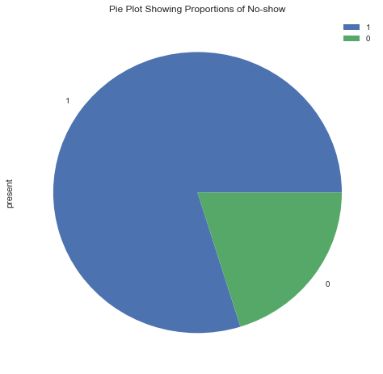

```python
#plotting the pe plot of present column

df['present'].value_counts().plot(kind='pie',figsize=(8,8))
plt.title('Pie Plot Showing Proportions of No-show')
plt.legend()
```